# Activity 3: Summary statistics, frequency distribution, and basic graphical representation

Jae Salazar

01 June 2026

# *Descriptive statistics*

## **Step 1** | Read in the CSV file as a dataframe using the function “read.csv”. Make sure to clean the data prior to performing the tasks below. Do not attempt to clean the data in Excel. Perform all cleaning (e.g., NA removal) in R using the code we discussed.

```r
herpedata <- data.frame(read.csv("D:/Files//DLSU Files/Year 3 Term 3/LBBBI27/Activity 3/herpetozoa-033-095-s001.csv"))
cleaningdata <- complete.cases(herpedata)
herpeclean <- herpedata[cleaningdata, ]
herpeclean
```

```
##           Sites     Long     Lat Htypes Elev SPPTotal Babu Inph Liac Lipa Ocla
## 1      ASG_ET1# 118.3962 9.37437    ASG  257        0    0    0    0    0    0
## 2      ASG_ET4# 118.3990 9.37250    ASG  215        0    0    0    0    0    0
## 3      ESG_ET5# 118.4008 9.37183    ESG  188        0    0    0    0    0    0
## 4       CVT_ET6 118.4056 9.36728    CVT  105        0    0    0    0    0    0
## 5       OGF_ET8 118.3861 9.37160    OGF  662        1    0    0    0    0    0
## 6      OGF_ET10 118.3840 9.37247    OGF  754        1    0    0    0    0    0
## 7      OGF_ET12 118.3836 9.37583    OGF  814        1    0    0    0    0    0
## 8       OGF_MT1 118.3183 9.34486    OGF 1020        1    0    0    0    0    0
## 9       OGF_MT4 118.3185 9.33391    OGF  474        1    0    0    0    0    0
## 10   OGF_ALAMT1 118.2051 9.37192    OGF  425        1    0    0    0    0    0
## 11   OGF_ALAMT2 118.2079 9.37277    OGF  507        1    0    0    0    0    0
## 12   OGF_ALAMT3 118.2098 9.37354    OGF  537        1    0    0    0    0    0
## 13   OGF_ALAMT5 118.2137 9.37574    OGF  686        1    0    0    0    0    0
## 14   CVT_ALAMT7 118.2173 9.37453    CVT  778        1    0    0    0    0    0
```

[output cut: 135 more lines]

## **Step 2** | Show the data structure.

```r
class(herpeclean)
```

```
## [1] "data.frame"
```

## **Step 3** | Subset the elevation data and provide the mean, standard deviation, and range.

```r
elevation <- herpeclean["Elev"]
elevationdata <- c(sapply(elevation, mean), sapply(elevation, sd), sapply(elevation, range))
elevationdata
```

```
##      Elev      Elev
##  379.3878  240.5951   60.0000 1020.0000
```

## **Step 4** | Subset the species data (columns G to AG) and count the total number of observations per species. Show two methods, using a typical loop and a compact loop.

```r
names(herpeclean)
```

```
##  [1] "Sites"    "Long"     "Lat"      "Htypes"   "Elev"     "SPPTotal"
##  [7] "Babu"     "Inph"     "Liac"     "Lipa"     "Ocla"     "Leta"
## [13] "Meli"     "Chfu"     "Pumo"     "Sasa"     "Stnu"     "Phev"
## [19] "Phlo"     "Pole"     "Poma"     "Brsp"     "Cyre"     "Geat"
## [25] "Gege"     "Gemo"     "Hety"     "Eumu"     "Bosc"     "Dema"
## [31] "Drru"     "Apbo"     "Trsu"
```

```r
speciesdata <- herpeclean[, 7:33]
```

## *Typical loop*

```r
## Placeholder to create the speciestotals object for use in the typical loop
speciestotals <- 0
for(i in seq_len(ncol(speciesdata))) {
    speciestotals[i] <- print(sum(speciesdata[i]))
 }
```

```
## [1] 1
## [1] 4
## [1] 28
## [1] 2
## [1] 5
## [1] 39
## [1] 17
## [1] 7
## [1] 51
## [1] 8
## [1] 35
## [1] 2
## [1] 377
## [1] 2
## [1] 5
## [1] 6
## [1] 7
## [1] 1
## [1] 5
## [1] 7
## [1] 1
## [1] 2
## [1] 1
## [1] 2
## [1] 1
## [1] 1
## [1] 2
```

```r
speciestotal <- matrix(speciestotals, nrow = 27, ncol = 1)
dimnames(speciestotal) <- list(names(speciesdata), "Total")
speciestotal
```

```
##      Total
## Babu     1
## Inph     4
## Liac    28
## Lipa     2
## Ocla     5
## Leta    39
## Meli    17
## Chfu     7
## Pumo    51
## Sasa     8
## Stnu    35
## Phev     2
## Phlo   377
## Pole     2
## Poma     5
## Brsp     6
## Cyre     7
## Geat     1
## Gege     5
## Gemo     7
## Hety     1
## Eumu     2
## Bosc     1
## Dema     2
## Drru     1
## Apbo     1
## Trsu     2
```

## *Compact loop*

```r
speciestotal <- matrix(sapply(speciesdata, sum))
dimnames(speciestotal) <- list(names(speciesdata), "Total")
speciestotal
```

```
##      Total
## Babu     1
## Inph     4
## Liac    28
## Lipa     2
## Ocla     5
## Leta    39
## Meli    17
## Chfu     7
## Pumo    51
## Sasa     8
## Stnu    35
## Phev     2
## Phlo   377
## Pole     2
## Poma     5
## Brsp     6
## Cyre     7
## Geat     1
## Gege     5
## Gemo     7
## Hety     1
## Eumu     2
## Bosc     1
## Dema     2
## Drru     1
## Apbo     1
## Trsu     2
```

```r
## Phlo has the highest (377), Babu, Geat, Hety, Bosc, Drru, Apbo have the lowest (1)
```

## **Step 5** | Combine the columns of species with the most and fewest observations with habitat types (Htypes). Determine the mean count of these species in each habitat type.

```r
specieshabitats <- herpeclean[c("Htypes", "Phlo", "Babu", "Geat", "Hety", "Bosc", "Drru", "Apbo")]
specieshabitats
```

```
##    Htypes Phlo Babu Geat Hety Bosc Drru Apbo
## 1     ASG    0    0    0    0    0    0    0
## 2     ASG    0    0    0    0    0    0    0
## 3     ESG    0    0    0    0    0    0    0
## 4     CVT    0    0    0    0    0    0    0
## 5     OGF    3    0    0    0    0    0    0
## 6     OGF    7    0    0    0    0    0    0
## 7     OGF   22    0    0    0    0    0    0
## 8     OGF   30    0    0    0    0    0    0
## 9     OGF    1    0    0    0    0    0    0
## 10    OGF    5    0    0    0    0    0    0
## 11    OGF   30    0    0    0    0    0    0
## 12    OGF   22    0    0    0    0    0    0
## 13    OGF   19    0    0    0    0    0    0
## 14    CVT    8    0    0    0    0    0    0
```

[output cut: 35 more lines]

```r
## Subset into habitats
ASG <- specieshabitats[specieshabitats$Htypes == "ASG", -1]
ESG <- specieshabitats[specieshabitats$Htypes == "ESG", -1]
CVT <- specieshabitats[specieshabitats$Htypes == "CVT", -1]
OGF <- specieshabitats[specieshabitats$Htypes == "OGF", -1]

## Generate means per habitats
ASGdata <- sapply(ASG, mean)
ESGdata <- sapply(ESG, mean)
CVTdata <- sapply(CVT, mean)
OGFdata <- sapply(OGF, mean)

## Combine the means into one matrix
habitatdata <- cbind(ASGdata, CVTdata, ESGdata, OGFdata)
habitatdata
```

```
##         ASGdata CVTdata ESGdata     OGFdata
## Phlo 1.46666667       4       0 15.08695652
## Babu 0.00000000       0       0  0.04347826
## Geat 0.00000000       0       0  0.04347826
## Hety 0.06666667       0       0  0.00000000
## Bosc 0.06666667       0       0  0.00000000
## Drru 0.06666667       0       0  0.00000000
## Apbo 0.00000000       0       0  0.04347826
```

```r
## OGF has the highest species counts, ESG has none.
```

# *Graphical representation*

## **Step 1** | From the original dataframe, combine the species total count column (SPPTotal) with the elevation and habitat type columns and create a scatter plot where elevation should be on the x-axis, while species total count is on the y-axis. Change the point colors based on habitat type.

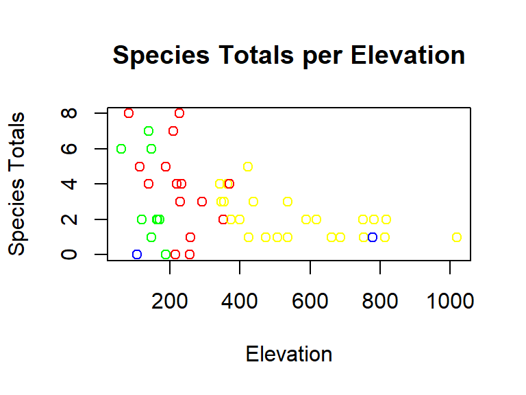

```r
plotdata <- herpeclean[4:6]
colors <- c(ASG = "red", CVT = "blue", ESG = "green", OGF = "yellow")
## Generate scatterplot
plot(plotdata$Elev, plotdata$SPPTotal, col = colors[plotdata$Htypes], main = "Species Totals per Elevation", xlab = "Elevation", ylab = "Species Totals")
```

## **Step 2** | From the combined data of species total counts, elevation, and habitat types, determine the total/sum number of species observed per habitat, and create a bar plot (use the bar plot help) where the x-axis shows the habitat types and the y-axis shows the total species.

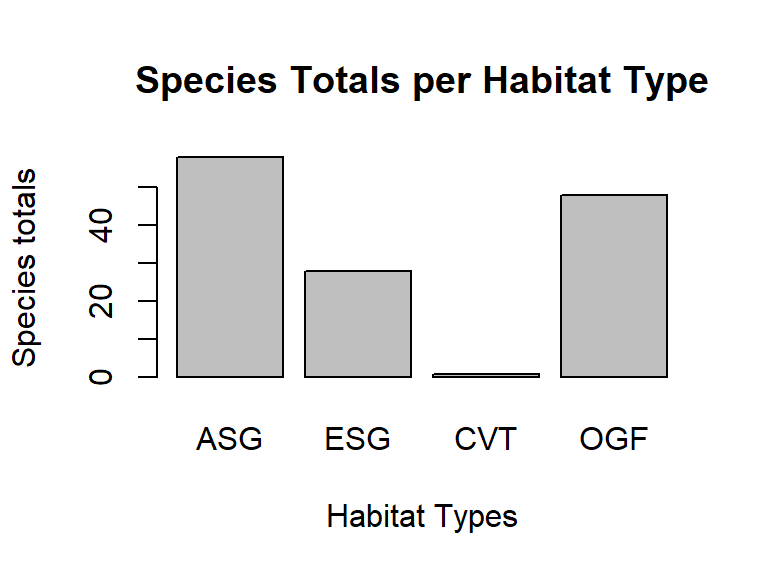

```r
ASGtotal <- plotdata[plotdata$Htypes == "ASG", -(1:2)]
ESGtotal <- plotdata[plotdata$Htypes == "ESG", -(1:2)]
CVTtotal <- plotdata[plotdata$Htypes == "CVT", -(1:2)]
OGFtotal <- plotdata[plotdata$Htypes == "OGF", -(1:2)]
## Combine sums of the subsets for barplot data
bardata <- c(sum(ASGtotal), sum(ESGtotal), sum(CVTtotal), sum(OGFtotal))
## Generate barplot
barplot(bardata, main = "Species Totals per Habitat Type", xlab = "Habitat Types", ylab = "Species totals", names.arg = c("ASG", "ESG", "CVT", "OGF"))
```

## **Step 3** | Lastly, create a histogram of total species counts using the histogram function. Make sure all axes are properly labeled.

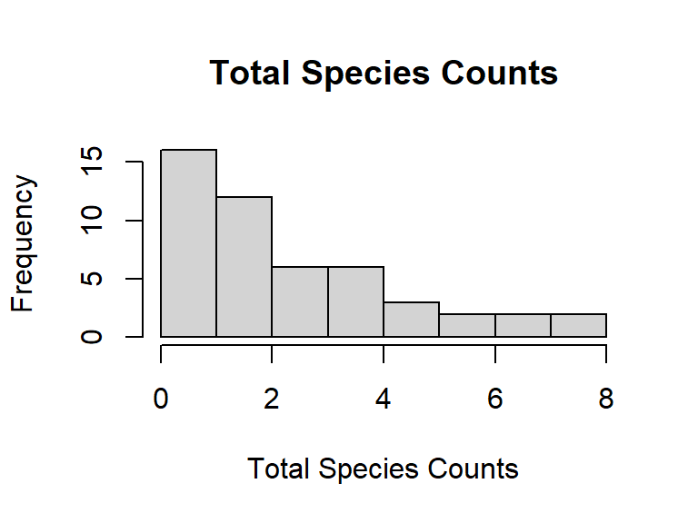

```r
hist(plotdata$SPPTotal, main = "Total Species Counts", xlab = "Total Species Counts", ylab = "Frequency")
```